# IS 670 Lab 4: Decision Tree vs Naive Bayes

This data set contains information of cars purchased at the Auction.  
We will use this file to predict the quality of buying decisions and visualize decision processes.  
VARIABLE DESCRIPTIONS:  
Auction: Auction provider at which the vehicle was purchased  
Color: Vehicle Color  
IsBadBuy: Identifies if the kicked vehicle was an avoidable purchase  
MMRCurrentAuctionAveragePrice: Acquisition price for this vehicle in average condition as of current day  
Size: The size category of the vehicle (Compact, SUV, etc.)  
TopThreeAmericanName:Identifies if the manufacturer is one of the top three American manufacturers  
VehBCost: Acquisition cost paid for the vehicle at time of purchase  
VehicleAge: The Years elapsed since the manufacturer's year  
VehOdo: The vehicles odometer reading  
WarrantyCost: Warranty price (term=36month and millage=36K)  
WheelType: The vehicle wheel type description (Alloy, Covers)  
Target variable: **IsBadBuy**

### 1. Upload and clean data

```python
# Mounting Google Drive
from google.colab import drive
drive.mount('/content/drive')
```

```python
# Import libraries
import pandas as pd
from sklearn.model_selection import train_test_split
from matplotlib import pyplot as plt
from sklearn import tree
from sklearn.tree import DecisionTreeClassifier
from sklearn.metrics import confusion_matrix
from sklearn.metrics import ConfusionMatrixDisplay
from sklearn.metrics import classification_report
from sklearn.naive_bayes import MultinomialNB
```

```python
# Read data
car_kick = pd.read_csv("/content/drive/MyDrive/IS 670/car_kick.csv")
car_kick
```

|  | PurchDate | VehYear | VehicleAge | VehOdo | MMRAcquisitionAuctionAveragePrice | MMRAcquisitionAuctionCleanPrice | MMRAcquisitionRetailAveragePrice | MMRAcquisitonRetailCleanPrice | MMRCurrentAuctionAveragePrice | MMRCurrentAuctionCleanPrice | ... | WheelTypeID | WheelType | Nationality | Size | TopThreeAmericanName | BYRNO | VNZIP1 | VNST | IsOnlineSale | IsBadBuy |
| --- | --- | --- | --- | --- | --- | --- | --- | --- | --- | --- | --- | --- | --- | --- | --- | --- | --- | --- | --- | --- | --- |
| 0 | 1289952000 | 2006 | 4 | 51954 | 6197 | 7062 | 9605 | 10426 | 5341 | 6351 | ... | 2 | Covers | AMERICAN | MEDIUM | CHRYSLER | 99750 | 32124 | FL | 0 | 0 |
| 1 | 1242691200 | 2005 | 4 | 89127 | 3688 | 4783 | 4483 | 5666 | 3688 | 4783 | ... | 2 | Covers | AMERICAN | MEDIUM | FORD | 20833 | 78754 | TX | 0 | 0 |
| 2 | 1248220800 | 2006 | 3 | 71271 | 6897 | 8449 | 7949 | 9625 | 6868 | 8549 | ... | 1 | Alloy | AMERICAN | LARGE | GM | 22916 | 80011 | CO | 0 | 0 |
| 3 | 1285718400 | 2008 | 2 | 83338 | 7878 | 8925 | 11723 | 13026 | 7801 | 8704 | ... | 2 | Covers | AMERICAN | LARGE | GM | 23657 | 94544 | CA | 0 | 0 |
| 4 | 1237334400 | 2007 | 2 | 58698 | 8800 | 10091 | 10004 | 11398 | 7355 | 8543 | ... | 1 | Alloy | AMERICAN | LARGE | GM | 20833 | 77086 | TX | 0 | 0 |
| ... | ... | ... | ... | ... | ... | ... | ... | ... | ... | ... | ... | ... | ... | ... | ... | ... | ... | ... | ... | ... | ... |
| 67206 | 1285804800 | 2008 | 2 | 56072 | 6255 | 6972 | 9852 | 10567 | 6326 | 7126 | ... | 2 | Covers | AMERICAN | MEDIUM | CHRYSLER | 22808 | 77061 | TX | 0 | 1 |
| 67207 | 1274918400 | 2004 | 6 | 94232 | 8359 | 9645 | 12042 | 13302 | 7505 | 8188 | ... | 1 | Alloy | 'TOP LINE ASIAN' | 'MEDIUM SUV' | OTHER | 17675 | 28273 | NC | 0 | 1 |
| 67208 | 1280448000 | 2004 | 6 | 79534 | 2805 | 3826 | 6132 | 6871 | 3106 | 4479 | ... | 1 | Alloy | AMERICAN | MEDIUM | GM | 18880 | 37771 | TN | 0 | 1 |
| 67209 | 1285200000 | 2003 | 7 | 79394 | 4042 | 5296 | 7335 | 8983 | 3534 | 4732 | ... | 2 | Covers | AMERICAN | 'MEDIUM SUV' | GM | 23657 | 92337 | CA | 0 | 1 |
| 67210 | 1288742400 | 2004 | 6 | 94491 | 5194 | 6424 | 8532 | 9941 | 4417 | 5807 | ... | 1 | Alloy | 'OTHER ASIAN' | MEDIUM | OTHER | 835 | 87105 | NM | 0 | 1 |

67211 rows × 31 columns

```python
car_kick.keys()
```

```
Index(['PurchDate', 'VehYear', 'VehicleAge', 'VehOdo',
       'MMRAcquisitionAuctionAveragePrice', 'MMRAcquisitionAuctionCleanPrice',
       'MMRAcquisitionRetailAveragePrice', 'MMRAcquisitonRetailCleanPrice',
       'MMRCurrentAuctionAveragePrice', 'MMRCurrentAuctionCleanPrice',
       'MMRCurrentRetailAveragePrice', 'MMRCurrentRetailCleanPrice',
       'VehBCost', 'WarrantyCost', 'Auction', 'Make', 'Model', 'Trim',
       'SubModel', 'Color', 'Transmission', 'WheelTypeID', 'WheelType',
       'Nationality', 'Size', 'TopThreeAmericanName', 'BYRNO', 'VNZIP1',
       'VNST', 'IsOnlineSale', 'IsBadBuy'],
      dtype='object')
```

```python
# Select the desired columns only
desired_columns = ['Auction', 'Color', 'IsBadBuy', 'MMRCurrentAuctionAveragePrice', 'Size','TopThreeAmericanName',
'VehBCost', 'VehicleAge', 'VehOdo', 'WarrantyCost', 'WheelType']
car_kick_desired = car_kick [desired_columns]
```

```python
# Replacing 1 with Yes and 0 with No in the target column IsBadBuy
carAuction = car_kick_desired.copy() #why?
carAuction['IsBadBuy'] = carAuction['IsBadBuy'].replace({0: 'No', 1: 'Yes'})
```

```python
# Examine missing values again
carAuction.isnull().sum()
```

|  | 0 |
| --- | --- |
| Auction | 0 |
| Color | 0 |
| IsBadBuy | 0 |
| MMRCurrentAuctionAveragePrice | 0 |
| Size | 0 |
| TopThreeAmericanName | 0 |
| VehBCost | 0 |
| VehicleAge | 0 |
| VehOdo | 0 |
| WarrantyCost | 0 |
| WheelType | 0 |

**dtype:** int64

```python
# Examine variable type
carAuction.dtypes
```

|  | 0 |
| --- | --- |
| Auction | object |
| Color | object |
| IsBadBuy | object |
| MMRCurrentAuctionAveragePrice | int64 |
| Size | object |
| TopThreeAmericanName | object |
| VehBCost | int64 |
| VehicleAge | int64 |
| VehOdo | int64 |
| WarrantyCost | int64 |
| WheelType | object |

**dtype:** object

```python
# Change categorical variables to "category"
carAuction['Auction'] = carAuction['Auction'].astype('category')
carAuction['Color'] = carAuction['Color'].astype('category')
carAuction['IsBadBuy'] = carAuction['IsBadBuy'].astype('category')
carAuction['Size'] = carAuction['Size'].astype('category')
carAuction['TopThreeAmericanName'] = carAuction['TopThreeAmericanName'].astype('category')
carAuction['WheelType'] = carAuction['WheelType'].astype('category')
```

```python
# Examine variable type
carAuction.dtypes
```

|  | 0 |
| --- | --- |
| Auction | category |
| Color | category |
| IsBadBuy | category |
| MMRCurrentAuctionAveragePrice | int64 |
| Size | category |
| TopThreeAmericanName | category |
| VehBCost | int64 |
| VehicleAge | int64 |
| VehOdo | int64 |
| WarrantyCost | int64 |
| WheelType | category |

**dtype:** object

## 2. Partition the data set for Decision Tree model

```python
# 1. Use the cleaned dataframe (carAuction) which has "Yes/No" labels
# Create dummy variables - this will create 'IsBadBuy_Yes'
car_kick_dummies = pd.get_dummies(carAuction, drop_first=True)

# 2. Define the target and predictors
# Now that we have dummy variables, the target column is 'IsBadBuy_Yes'
target_col = 'IsBadBuy_Yes'
predictors = car_kick_dummies.drop(target_col, axis=1)
target = car_kick_dummies[target_col]

# 3. Partition the data (70% Train, 30% Test)
predictors_train, predictors_test, target_train, target_test = train_test_split(
    predictors, target, test_size=0.3, random_state=1, stratify=target
)

# 4. Balance the training data using Undersampling
# Combine train predictors and target for sampling
combined_train_df = pd.concat([predictors_train, target_train], axis=1)

# Separate Majority (0 = No) and Minority (1 = Yes)
majority_df = combined_train_df[combined_train_df[target_col] == 0]
minority_df = combined_train_df[combined_train_df[target_col] == 1]

# Randomly sample the majority to match the minority count
undersampled_majority = majority_df.sample(n=len(minority_df), random_state=1)
balanced_data = pd.concat([undersampled_majority, minority_df]).sample(frac=1, random_state=1)

# Final balanced training sets
predictors_train = balanced_data.drop(columns=[target_col])
target_train = balanced_data[target_col]

print("Balanced Training Set Size:", predictors_train.shape)
print("Target proportions in balanced training set:")
print(target_train.value_counts(normalize=True))
```

```
Balanced Training Set Size: (8982, 38)
Target proportions in balanced training set:
IsBadBuy_Yes
False    0.5
True     0.5
Name: proportion, dtype: float64
```

## 3. Decision Tree model prediction

```python
# Build Decision Tree
model_DT = DecisionTreeClassifier(criterion="entropy", random_state=1, max_depth=3)
model_DT.fit(predictors_train, target_train)
```

```
DecisionTreeClassifier(criterion='entropy', max_depth=3, random_state=1)
```

[output not shown]

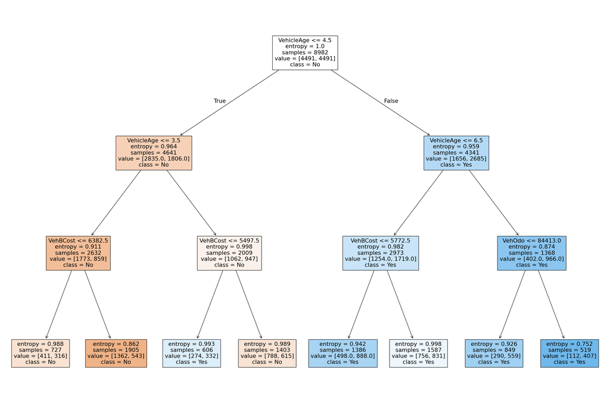

```python
# Plot the tree
fig = plt.figure(figsize=(30,20))
tree.plot_tree(model_DT,
               feature_names=list(predictors_train.columns),
               class_names=['No','Yes'],
               filled=True)
```

```python
# Text version of decision tree
# We use predictors_train.columns because it contains the names of the 38 dummy features the model learned.
print(tree.export_text(model_DT, feature_names=list(predictors_train.columns)))
```

```
|--- VehicleAge <= 4.50
|   |--- VehicleAge <= 3.50
|   |   |--- VehBCost <= 6382.50
|   |   |   |--- class: False
|   |   |--- VehBCost >  6382.50
|   |   |   |--- class: False
|   |--- VehicleAge >  3.50
|   |   |--- VehBCost <= 5497.50
|   |   |   |--- class: True
|   |   |--- VehBCost >  5497.50
|   |   |   |--- class: False
|--- VehicleAge >  4.50
|   |--- VehicleAge <= 6.50
|   |   |--- VehBCost <= 5772.50
|   |   |   |--- class: True
|   |   |--- VehBCost >  5772.50
|   |   |   |--- class: True
|   |--- VehicleAge >  6.50
|   |   |--- VehOdo <= 84413.00
|   |   |   |--- class: True
|   |   |--- VehOdo >  84413.00
|   |   |   |--- class: True
```

```python
# Make predictions on testing data
prediction_on_test_DT = model_DT.predict(predictors_test)
```

```
<sklearn.metrics._plot.confusion_matrix.ConfusionMatrixDisplay at 0x7c7a30fd83e0>
```

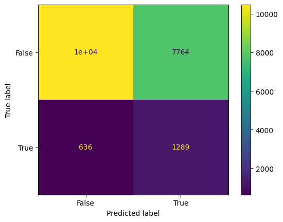

```python
# Examine the evaluation results on testing data: confusion_matrix
cm_DT = confusion_matrix(target_test, prediction_on_test_DT)
ConfusionMatrixDisplay(confusion_matrix=cm_DT, display_labels=model_DT.classes_).plot()
```

```python
# Examine the evaluation results on testing data: accuracy, precision, recall, and f1-score
print(classification_report(target_test, prediction_on_test_DT))
```

```
              precision    recall  f1-score   support

       False       0.94      0.57      0.71     18239
        True       0.14      0.67      0.23      1925

    accuracy                           0.58     20164
   macro avg       0.54      0.62      0.47     20164
weighted avg       0.87      0.58      0.67     20164
```

## 3. Naive Bayes model prediction

```python
# Build a Naive Bayes model on training data with default setting
model_NB = MultinomialNB()
model_NB.fit(predictors_train, target_train)
```

```
MultinomialNB()
```

```python
# Make predictions on testing data
prediction_on_test_NB = model_NB.predict(predictors_test)
```

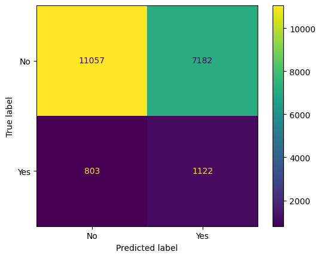

```python
# Examine the evaluation results on testing data: confusion_matrix
cm_NB = confusion_matrix(target_test, prediction_on_test_NB)
ConfusionMatrixDisplay(confusion_matrix=cm_NB, display_labels=['No', 'Yes']).plot()
plt.show()
```

```python
# Examine the evaluation results on testing data: accuracy, precision, recall, and f1-score
print(classification_report(target_test, prediction_on_test_NB))
```

```
              precision    recall  f1-score   support

       False       0.93      0.61      0.73     18239
        True       0.14      0.58      0.22      1925

    accuracy                           0.60     20164
   macro avg       0.53      0.59      0.48     20164
weighted avg       0.86      0.60      0.69     20164
```

Answer Q1 to Q5 based on the **NB model**.

Q1. On the testing set, how many Yes (bad buy) cars are predicted as No (not bad buy)? Answer: 803

This is the count of False Negatives (bottom-left square). These are cars that were actually "Bad Buys" but the model incorrectly flagged them as safe to buy.

Q2. On the testing set, how many cars are predicted as Not bad buy?Answer: 11,860This is the sum of the entire "No" column under "Predicted label".Calculation: $11,057$ (True Negatives) $+ 803$ (False Negatives) $= 11,860$.

Q3. On the testing set, how many bad buy cars are identified correctly? Answer: 1,122

This is the count of True Positives (bottom-right square). These are the "Bad Buy" cars the model successfully caught.

Q4. If the model predicts a car as a bad buy, what is the probability that such prediction is correct? (Precision)Answer: ~13.51%This is the Precision for the "Yes" class.Calculation: $\frac{True Positives}{Total Predicted Yes} = \frac{1,122}{1,122 + 7,182} = \frac{1,122}{8,304} \approx 0.1351$.

Q5. What percentage of kick cars can be detected by this model? (Recall)Answer: ~58.29%This is the Recall for the "Yes" class.Calculation: $\frac{True Positives}{Total Actual Yes} = \frac{1,122}{1,122 + 803} = \frac{1,122}{1,925} \approx 0.5829$.

The Naive Bayes model here has a decent recall (~58%) but very low precision (~13.5%), meaning it flags a lot of "False Alarms" (7,182 good cars marked as bad buys).

Q7. Examine and explain which model has a better performance on the **train** set? Run the necessary code in the cell below.

```python
# Check accuracy on training data for both models
print("DT Train Accuracy:", model_DT.score(predictors_train, target_train))
print("NB Train Accuracy:", model_NB.score(predictors_train, target_train))
```

```
DT Train Accuracy: 0.621019817412603
NB Train Accuracy: 0.6032064128256514
```

Q8. Why should one get the models' performance on the training set when we have the testing set?

Checking the training set allows you to detect overfitting.

If a model performs perfectly on the training data but poorly on the testing data, it has "memorized" the specific rows instead of learning general patterns.

```python
# Check if the file exists in the IS 670 folder and convert
!jupyter nbconvert --to html "/content/drive/MyDrive/IS 670/IS670_lab04.ipynb"
```

```
[NbConvertApp] Converting notebook /content/drive/MyDrive/IS 670/IS670_lab04.ipynb to html
[NbConvertApp] WARNING | Alternative text is missing on 3 image(s).
[NbConvertApp] Writing 853673 bytes to /content/drive/MyDrive/IS 670/IS670_lab04.html
```